# lab_09_modeling2

Analysis of Environmental Data Lab 634

Emma Zimmerman Greenlee

2021-11-10

# Prelab

### Load the Data Files

```r
require(here)
catrate = read.csv(here("data", "catrate.csv"))
head(catrate)
```

```
##   pond success years  cat.rate
## 1    2       5     7 0.2857143
## 2    3       5     7 0.2857143
## 3    4       6     7 0.1428571
## 4    5       4     7 0.4285714
## 5    6       0     7 1.0000000
## 6    7       1     4 0.7500000
```

## Binomial Test for Proportions

### Reproductive Success and Failure

```r
n_success = sum(catrate$success)
n_years = sum(catrate$years)
binom.test(n_success, n_years)
```

```
##
##  Exact binomial test
##
## data:  n_success and n_years
## number of successes = 33, number of trials = 61, p-value = 0.6089
## alternative hypothesis: true probability of success is not equal to 0.5
## 95 percent confidence interval:
##  0.4084989 0.6693559
## sample estimates:
## probability of success
##              0.5409836
```

### Reproductive Catastrophe and Late Filling

```r
late_fill_rate = 2/7
normal_fill_rate = 1 - late_fill_rate

# Two-sided alternative hypothesis
binom.test(
  n_success,
  n_years,
  p = normal_fill_rate)
```

```
##
##  Exact binomial test
##
## data:  n_success and n_years
## number of successes = 33, number of trials = 61, p-value = 0.004227
## alternative hypothesis: true probability of success is not equal to 0.7142857
## 95 percent confidence interval:
##  0.4084989 0.6693559
## sample estimates:
## probability of success
##              0.5409836
```

```r
# One-sided alternative hypothesis
binom.test(
  n_success,
  n_years,
  p = normal_fill_rate,
  alternative ='less')
```

```
##
##  Exact binomial test
##
## data:  n_success and n_years
## number of successes = 33, number of trials = 61, p-value = 0.002984
## alternative hypothesis: true probability of success is less than 0.7142857
## 95 percent confidence interval:
##  0.0000000 0.6507238
## sample estimates:
## probability of success
##              0.5409836
```

## Two Sample Tests

### F-distribution Example: Vegetation Data

```r
veg = read.csv(here("data", "vegdata.csv"))
head(veg)
```

```
##   block plot date treatment birch pine fern
## 1     A   A3 1995   control     0    4  260
## 2     A   A7 1995   control     0    0  186
## 3     A   A4 1995   removed     8    8   46
## 4     A   A6 1995   removed     6   28    1
## 5     A   A5 1995     mixed     0    1  309
## 6     A   A8 1995     mixed     0    0  258
```

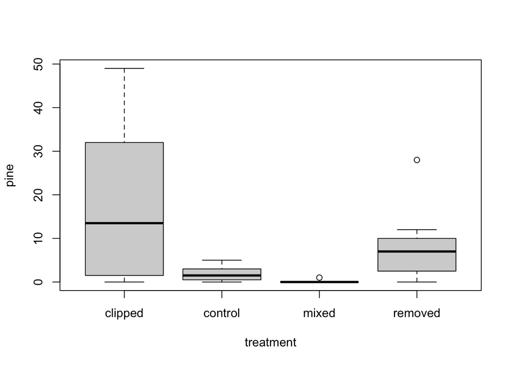

```r
boxplot(pine ~ treatment, data = veg)
```

### Variance test

```r
var.test(
  pine ~ treatment,
  data = veg,
  subset = treatment %in% c('control','clipped'))
```

```
##
##  F test to compare two variances
##
## data:  pine by treatment
## F = 119.3, num df = 7, denom df = 7, p-value = 1.92e-06
## alternative hypothesis: true ratio of variances is not equal to 1
## 95 percent confidence interval:
##   23.88333 595.86810
## sample estimates:
## ratio of variances
##           119.2951
```

### F-tests Assumes Normality

```r
shapiro.test(veg$pine[veg$treatment=="control"])
```

```
##
##  Shapiro-Wilk normality test
##
## data:  veg$pine[veg$treatment == "control"]
## W = 0.89397, p-value = 0.2547
```

```r
shapiro.test(veg$pine[veg$treatment=="clipped"])
```

```
##
##  Shapiro-Wilk normality test
##
## data:  veg$pine[veg$treatment == "clipped"]
## W = 0.81806, p-value = 0.04452
```

### Non-parametric Variance Test

```r
fligner.test(
  pine ~ treatment,
  data = veg,
  subset = treatment %in% c('control','clipped'))
```

```
##
##  Fligner-Killeen test of homogeneity of variances
##
## data:  pine by treatment
## Fligner-Killeen:med chi-squared = 8.3686, df = 1, p-value = 0.003818
```

```r
bartlett.test(pine ~ treatment, data = veg)
```

```
##
##  Bartlett test of homogeneity of variances
##
## data:  pine by treatment
## Bartlett's K-squared = 63.741, df = 3, p-value = 9.323e-14
```

```r
fligner.test(pine ~ treatment, data = veg)
```

```
##
##  Fligner-Killeen test of homogeneity of variances
##
## data:  pine by treatment
## Fligner-Killeen:med chi-squared = 19.707, df = 3, p-value = 0.0001952
```

## Comparing two sample means

### T-test

```r
t.test(
  pine ~ treatment,
  data = veg,
  subset = treatment %in% c('control','clipped'))
```

```
##
##  Welch Two Sample t-test
##
## data:  pine by treatment
## t = 2.2825, df = 7.1173, p-value = 0.05582
## alternative hypothesis: true difference in means between group clipped and group control is not equal to 0
## 95 percent confidence interval:
##  -0.5204871 32.5204871
## sample estimates:
## mean in group clipped mean in group control
##                17.875                 1.875
```

### Wilcox test

```r
wilcox.test(
  pine ~ treatment,
  data = veg,
  subset = treatment %in% c('control','clipped'))
```

```
##
##  Wilcoxon rank sum test with continuity correction
##
## data:  pine by treatment
## W = 48, p-value = 0.1005
## alternative hypothesis: true location shift is not equal to 0
```

## Tests for paired samples

```r
control = veg$pine[veg$treatment=='control']
clipped = veg$pine[veg$treatment=='clipped']

t.test(control, clipped, paired=TRUE)
```

```
##
##  Paired t-test
##
## data:  control and clipped
## t = -2.3103, df = 7, p-value = 0.05417
## alternative hypothesis: true difference in means is not equal to 0
## 95 percent confidence interval:
##  -32.3765015   0.3765015
## sample estimates:
## mean of the differences
##                     -16
```

```r
wilcox.test(control, clipped, paired=TRUE)
```

```
##
##  Wilcoxon signed rank test with continuity correction
##
## data:  control and clipped
## V = 1, p-value = 0.03461
## alternative hypothesis: true location shift is not equal to 0
```

## Correlation

### Marbled Salamander

```r
disp = read.csv(here("data", "dispersal.csv")); disp
```

```
##    dist.class disp.rate.ftb disp.rate.eb
## 1         100          0.00          0.0
## 2         200          0.25          0.8
## 3         300          0.65          0.2
## 4         400          0.92          0.1
## 5         500          0.40          0.3
## 6         600          0.00          0.0
## 7         700            NA           NA
## 8         800          0.20          0.0
## 9         900          0.05          0.0
## 10       1000          0.00          0.0
## 11       1100          0.15          0.0
## 12       1200          0.00          0.0
## 13       1300          0.12          0.0
## 14       1400          0.00          0.0
## 15       1500          0.00          0.0
```

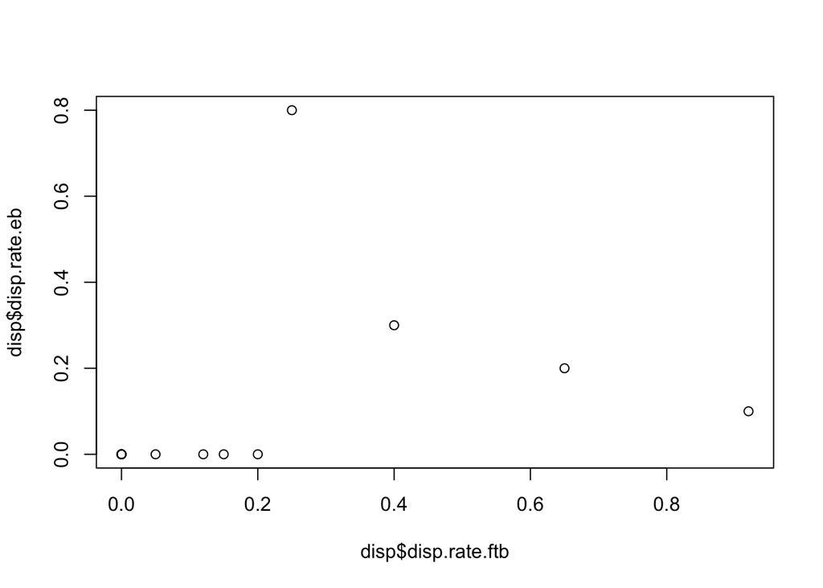

```r
plot(disp$disp.rate.ftb, disp$disp.rate.eb)
```

```r
# Test for significance
cor.test(
  disp$disp.rate.ftb,
  disp$disp.rate.eb,
  use='complete.obs')
```

```
##
##  Pearson's product-moment correlation
##
## data:  disp$disp.rate.ftb and disp$disp.rate.eb
## t = 1.2084, df = 12, p-value = 0.2502
## alternative hypothesis: true correlation is not equal to 0
## 95 percent confidence interval:
##  -0.2438293  0.7320180
## sample estimates:
##       cor
## 0.3293598
```

```r
cor.test(
  disp$disp.rate.ftb,
  disp$disp.rate.eb,
  use='complete.obs',
  method='spearman')
```

```
##
##  Spearman's rank correlation rho
##
## data:  disp$disp.rate.ftb and disp$disp.rate.eb
## S = 102.99, p-value = 0.001169
## alternative hypothesis: true rho is not equal to 0
## sample estimates:
##       rho
## 0.7736421
```

## Comparing two distributions

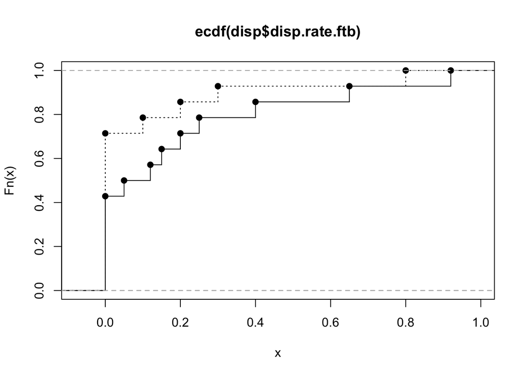

```r
plot(
  ecdf(disp$disp.rate.ftb),
  verticals=TRUE)
plot(
  ecdf(disp$disp.rate.eb),
  verticals=TRUE,
  lty=3,
  add=TRUE)
```

```r
ks.test(disp$disp.rate.ftb,disp$disp.rate.eb)
```

```
##
##  Two-sample Kolmogorov-Smirnov test
##
## data:  disp$disp.rate.ftb and disp$disp.rate.eb
## D = 0.28571, p-value = 0.6172
## alternative hypothesis: two-sided
```

## Comparing two or more proportions

### Sex-linked killing

```r
# Simple binomial proportions test
prop.test(c(4,16),c(40,250))
```

```
##
##  2-sample test for equality of proportions with continuity correction
##
## data:  c(4, 16) out of c(40, 250)
## X-squared = 0.24825, df = 1, p-value = 0.6183
## alternative hypothesis: two.sided
## 95 percent confidence interval:
##  -0.07629446  0.14829446
## sample estimates:
## prop 1 prop 2
##  0.100  0.064
```

## Dependence of variables in a contingency table

### Contingency: Chi-square test

```r
owls = matrix(c(16, 9, 4, 11), nrow=2)
rownames(owls) = c("present", "absent")
colnames(owls) = c("old", "young")
chisq.test(owls)
```

```
##
##  Pearson's Chi-squared test with Yates' continuity correction
##
## data:  owls
## X-squared = 3.84, df = 1, p-value = 0.05004
```

### Fisher’s Exact test

```r
fisher.test(owls)
```

```
##
##  Fisher's Exact Test for Count Data
##
## data:  owls
## p-value = 0.04837
## alternative hypothesis: true odds ratio is not equal to 1
## 95 percent confidence interval:
##   1.00906 26.52895
## sample estimates:
## odds ratio
##   4.683421
```

### Bird habitat data

```r
birds = read.csv(here("data", "bird.sta.csv"))
hab = read.csv(here("data", "hab.sta.csv"))
birdhab = merge(birds, hab, by=c("basin", "sub", "sta"))

# Create a contingency table for edge/interior and brown creeper presence/absence
table(birdhab$s.edge, birdhab$BRCR > 0)
```

```
##
##     FALSE TRUE
##   E   144   29
##   I   559  314
```

```r
# Set the presence to be in the first column
br_creeper_table = table(birdhab$s.edge, birdhab$BRCR > 0)[, 2:1]
```

# Lab Questions

### Chi-square Tests

```r
br_creeper_table
```

```
##
##     TRUE FALSE
##   E   29   144
##   I  314   559
```

```r
chisq.test(br_creeper_table)
```

```
##
##  Pearson's Chi-squared test with Yates' continuity correction
##
## data:  br_creeper_table
## X-squared = 23.3, df = 1, p-value = 1.386e-06
```

## Question 1

### State the null hypothesis of the Chi-square test.

The null hypothesis is that there is no corelation between the habitats (being edge or interior) and the presence (and absence) of Brown Creepers.

## Question 2

### Consider the results of your test and explain whether you think that Brown Creepers show a significant habitat preference.

Since the p-value from the Chi-square test was quite low (1.386e-06), which means that there is strong evidence to reject the null hypothesis, I do believe that Brown Creepers show a significant habitat preference (the opposite of what the null hypothesis states).

## Question 3

### Show the R-code you can use to create a model fit (call it fit_species) of penguin body mass as predicted by penguin species.

```r
require(palmerpenguins)
fit_species =
  lm(
    formula = body_mass_g ~ species,
    data = penguins)
```

## Question 4

### Show the R-code you can use to create a model fit (call it fit_sex) of penguin body mass as predicted by sex.

```r
fit_sex =
  lm(
    formula = body_mass_g ~ sex,
    data = penguins)
```

## Question 5

### Show the R-code you can use to create a model fit (call it fit_both) of penguin body mass as predicted by species and sex.

```r
fit_both =
  lm(
    formula = body_mass_g ~ species*sex,
    data = penguins)
```

## Question 6

### Include a conditional boxplot corresponding to your fit_species model.

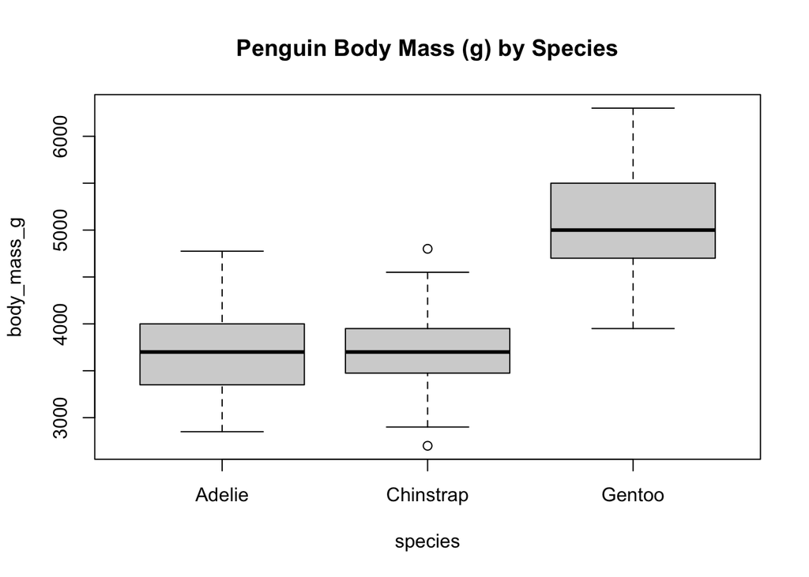

```r
boxplot(
  formula = body_mass_g ~ species,
  data = penguins,
  main = "Penguin Body Mass (g) by Species")
```

## Question 7

### Include a conditional boxplot corresponding to your fit_sex model.

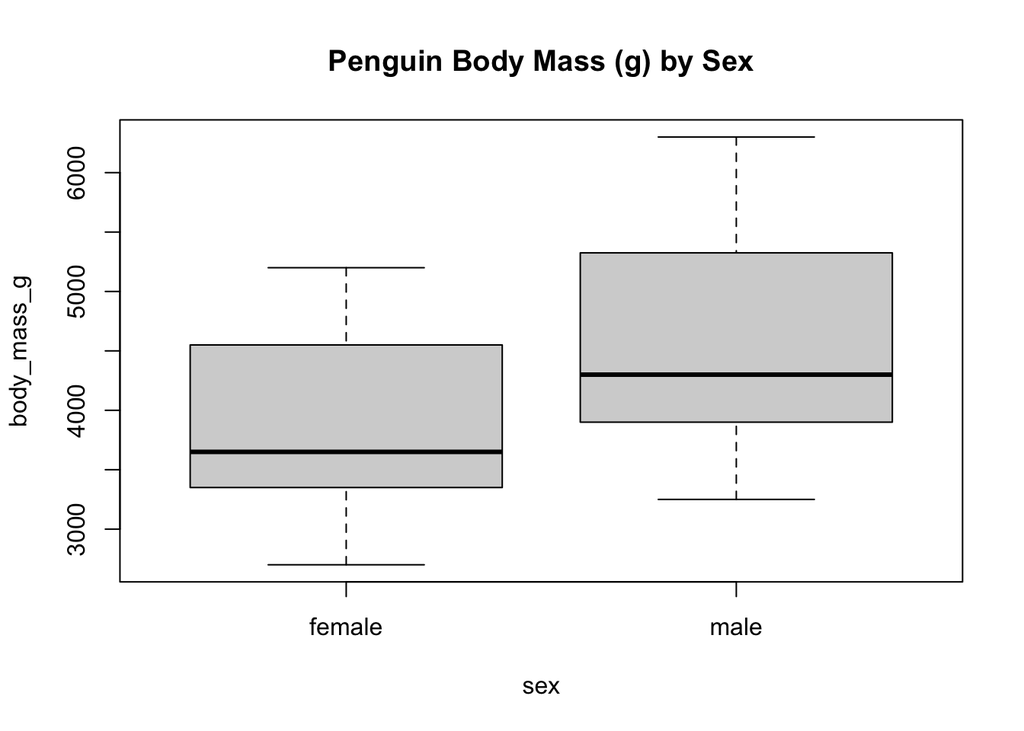

```r
boxplot(
  formula = body_mass_g ~ sex,
  data = penguins,
  main = "Penguin Body Mass (g) by Sex")
```

## Question 8

### Include a conditional boxplot corresponding to your fit_both model. Your group labels must all correspond to the correct box, be visible, and sensible.

[figure not shown]

```r
boxplot(
  formula = body_mass_g ~ species*sex,
  data = penguins,
  xlab = " ",
  main = "Penguin Body Mass (g) by Species and Sex",
  names = c("Adelie\nfemale", "Adelie\nmale", "Gentoo\nfemale",
            "Gentoo\nmale", "Chinstrap\nfemale", "Chinstrap\nmale"),
  las = 2)
```

## Question 10

### State the null hypothesis of the Bartlett test.

The null hypothesis is that the varience between the body mass of the penguin species and/or sex (depending on which we are testing) is completly the same.

## Question 11

### What was the p-value from the Bartlett test of homogeneity for observations grouped by species? You can round your answer to 4 decimal digits.

The p-value was 0.0501

```r
bartlett.test(body_mass_g ~ species, data = penguins)
```

```
##
##  Bartlett test of homogeneity of variances
##
## data:  body_mass_g by species
## Bartlett's K-squared = 5.9895, df = 2, p-value = 0.05005
```

## Question 12

### What was the p-value from the Bartlett test of homogeneity for observations grouped by sex? You can round your answer to 4 decimal digits.

The p-value was 0.0319.

```r
bartlett.test(body_mass_g ~ sex, data = penguins)
```

```
##
##  Bartlett test of homogeneity of variances
##
## data:  body_mass_g by sex
## Bartlett's K-squared = 4.6017, df = 1, p-value = 0.03194
```

## Question 13

### What was the p-value from the Bartlett test of homogeneity for observations grouped by both factors? You can round your answer to 4 decimal digits.

The p-value was 0.1741.

```r
dat_groups = aggregate(
  body_mass_g ~ species * sex,
  data = penguins,
  FUN = c)

bartlett.test(dat_groups$body_mass_g)
```

```
##
##  Bartlett test of homogeneity of variances
##
## data:  dat_groups$body_mass_g
## Bartlett's K-squared = 7.6908, df = 5, p-value = 0.1741
```